# Psychoinformatics - Week 4 (Exercises)

by 陳怡儒 (B06603039@ntu.edu.tw)

## 1 Analyze what videos go viral? (8 points)

Please use [YouTube APIs](https://developers.google.com/youtube/v3/code_samples/python) to carry out a data-driven or hypothesis-driven microstudy about the characteristics of viral videos.

You need to present, here in this notebook, AT LEAST two **statistical** figures or tables as supporting evidence for your arguments. Each of these figures/tables deserves 4 points.

### What's the Question?

NCC針對不同新聞頻道的報導公平原則在過去進行許多研究，試想，在NCC管不到的新聞平台，會不會更嚴重呢！？

這份報告以「陳柏惟罷免案」作為討論核心，討論以下三種情況

究竟會有怎樣的結果呢？讓我們繼續看下去...

ref: https://www.thenewslens.com/article/120423#&gid=1&pid=1

Q1. 不同新聞頻道對「陳柏惟」搜尋下的“total Result”有何不同？

Q2. 刪Q？

Q3. 反惡罷？

```python
DEVELOPER_KEY = "AIzaSyCVg6aiTEpc1dDBa7wnnsE6_RE0OD08lSs"  #exceed.....
# solve 換金鑰 ref: https://stackoverflow.com/questions/47408723/youtube-quotas-exceeded
from apiclient.discovery import build
youtube = build('youtube', 'v3', developerKey=DEVELOPER_KEY)

import pandas as pd
import matplotlib.pyplot as plt
import numpy as np
```

### 不同新聞頻道對「陳柏惟」搜尋下的 “Total Result”有何不同？

首先，得先找到不同新聞頻道在Youtube上的 ChannelID

```python
search_NewsChannel = youtube.search().list(q="新聞台-直播",type="channel",order = "relevance"
                                           ,part="snippet", maxResults=50,regionCode='TW').execute()
#print(search_NewsChannel)

channelId = []
channelTitle = []
for search_result in search_NewsChannel.get('items',[]):
        channelId.append(search_result['snippet']['channelId'])
        channelTitle.append(search_result['snippet']['channelTitle'])
NewsChannel = {'channelId': channelId,'channelTitle': channelTitle}

df = pd.DataFrame(data=NewsChannel)
df
```

[output not shown]

|  | channelId | channelTitle |
| --- | --- | --- |
| 0 | UCA_hK5eRICBdSOLlXKESvEg | 華視直播頻道 |
| 1 | UClIfopQZlkkSpM1VgCFLRJA | 民視直播 FTVN Live 53 |
| 2 | UCmH4q-YjeazayYCVHHkGAMA | 中視新聞 HD直播頻道｜Taiwan CTV news HD Live |
| 3 | UCO3bfz4KY6zGT5IOaFJuxpA | 中視新聞 |
| 4 | UCXgIO9jJVsX5_2ideiSkfvA | 台灣公共電視 網路直播頻道 |
| 5 | UC2TuODJhC03pLgd6MpWP0iw | 三立LIVE新聞 |
| 6 | UCHBv5vSp3pETSLq8oWTsmqA | 年代新聞CH50 |
| 7 | UCdqg95tSArchPfQaAWquDwg | 客家電視網路直播 Hakka Live |
| 8 | UCuzqko_GKcj9922M1gUo__w | 57東森財經新聞 |
| 9 | UCOc2A2GJ9-WhjZSUO3nVEgQ | 九八新聞台 |
| 10 | UC8ROUUjHzEQm-ndb69CX8Ww | 台視新聞 TTV NEWS |
| 11 | UCR3asjvr_WAaxwJYEDV_Bfw | 東森新聞 CH51 |
| 12 | UCDCJyLpbfgeVE9iZiEam-Kg | 華視新聞 CH52 |
| 13 | UCp2f7tGJGN6R9Muxipem8Nw | 寰宇新聞 頻道 |
| 14 | UC6hWBu1hfbNNk8Yeokd5aZQ | 壹電視NEXT TV |
| 15 | UC5l1Yto5oOIgRXlI4p4VKbw | 中天電視 |
| 16 | UCIU8ha-NHmLjtUwU7dFiXUA | 三立新聞網SETN |
| 17 | UCv-xeIaa6hSw8BuEyCzIg7Q | 客家新聞Hakka News |
| 18 | UCoNYj9OFHZn3ACmmeRCPwbA | 三立iNEWS |
| 19 | UCX6SRupi5lTDbIFJEOpReCQ | 公視台語台 |
| 20 | UC21BtM_TJfRfOyEWKlrBgfQ | 民視英語新聞 Formosa TV English News |
| 21 | UCpu3bemTQwAU8PqM4kJdoEQ | 中天新聞 |
| 22 | UCYIVkruUoN04UjV9pkBTswg | USTV 非凡電視 |
| 23 | UCX9OQTv_N1PCrgfXlT8KE8A | 八大民生新聞 |
| 24 | UCzZe-zMu-YgVFQfDmsFG_VQ | TTV LIVE 台視直播 |
| 25 | UC5nwNW4KdC0SzrhF9BXEYOQ | TVBS NEWS |
| 26 | UC2VmWn8dAqkzlQqvy02E1PA | 民視新聞網 Formosa TV News network |
| 27 | UCK1Zh_2KvKKFkDBCSYuLjAw | 57彩券王 |
| 28 | UC_ifDTtFAcsj-wJ5JfM27CQ | 無綫新聞 TVB NEWS official |
| 29 | UCkqrvXuqW7dN3E2_4v8Ha5Q | 中廣新聞網 |
| 30 | UChLEhd2gouo1H-c9Zy9WGDA | 蘋果新聞網 |
| 31 | UC5fkmrA5VDTr2IU7lPmpsHA | 新聞大白話 |
| 32 | UCexpzYDEnfmAvPSfG4xbcjA | 公視新聞網 |
| 33 | UCnAsZ46UTeFEgwOEwMezngQ | CCTV中文国际 |
| 34 | UCl3aKvzB7uC5mTlVEWiCogA | ETtoday新聞雲 |
| 35 | UC8DY8QDoLUE3G7yAFgYs9mw | 壹直播 |
| 36 | UCRvjnobFht8a6vW4BFVl1xQ | 不演了新聞台 |
| 37 | UCiqm4JC8lbGqgePjHd3Mahw | 運通財經台 |
| 38 | UCL0_NxCvkcXwZHpvqgMZY-A | TVBS選新聞 |
| 39 | UCHsKlGM7IXNnQqA6S8mEmBQ | 這!不是新聞 |
| 40 | UC8w76cjoqEArF-ns44l_ujA | 新聞面對面 |
| 41 | UCeQZRoB7L6vKnR8T7y1lt9A | 東森新聞 EBC LIVE |
| 42 | UCBuHkb1AS_yRQ71meFNQ3VQ | 年代向錢看 |
| 43 | UCwDyCMbrFn0RkqXdCKxjIbg | 驚爆新聞線 |
| 44 | UCi4AGjvmSMB9Nn6oyFPYPeQ | 新唐人亞太電視台NTDAPTV |
| 45 | UCwY3pld7Wp_dRO-Skc_HNXg | 凱擘大彰化新聞 |
| 46 | UCHycXkewR3NXQE59t3hhlaQ | 三大有線電視公司-三大一台 |
| 47 | UCLG2sbIo3Rktb77h6q9yuDw | 鄭知道了 |
| 48 | UCCqASHJXWs5_Lst_jWp40dw | 大新聞大爆卦 |
| 49 | UCd9dPMYgV9-IQaZG491TaRw | 鳳凰秀Fengshows |

針對「中視新聞」、「年代新聞CH50」、「台視新聞 TTV NEWS」、「華視新聞 CH52」、「東森新聞 CH51」、「寰宇新聞 頻道」、「壹電視NEXT TV」、「中天電視」、「TVBS NEWS」、「民視新聞網 Formosa TV News network」、「公視新聞網」這11家電視台頻道做討論。 資料依序放入ID array當中。

```python
TV=['中視新聞','年代新聞CH50','台視新聞 TTV NEWS','華視新聞 CH52','東森新聞 CH51','寰宇新聞 頻道',
    '壹電視NEXT TV', '中天電視', 'TVBS NEWS', '民視新聞網 Formosa TV News network', '公視新聞網']
TV_ENG=['CTV', 'ERA', 'TTV', 'CTS', 'EBC', 'GLOBAL', 'NEXT TV', 'CTI', 'TVBS', 'Formosa', 'PTS']
ID=['UCO3bfz4KY6zGT5IOaFJuxpA', 'UCHBv5vSp3pETSLq8oWTsmqA', 'UC8ROUUjHzEQm-ndb69CX8Ww', 'UCDCJyLpbfgeVE9iZiEam-Kg',
   'UCR3asjvr_WAaxwJYEDV_Bfw', 'UCp2f7tGJGN6R9Muxipem8Nw', 'UC6hWBu1hfbNNk8Yeokd5aZQ', 'UCpu3bemTQwAU8PqM4kJdoEQ',
   'UC5nwNW4KdC0SzrhF9BXEYOQ', 'UC2VmWn8dAqkzlQqvy02E1PA', 'UCexpzYDEnfmAvPSfG4xbcjA']

# RESULTS={'電視台頻道': TV,'頻道英文':TV_ENG,'channelID': ID}
# RS = pd.DataFrame(data=RESULTS)
# RS
```

[output not shown]

比較11家電視台頻道！？

想得美 QUOTAEXCEEDED ....

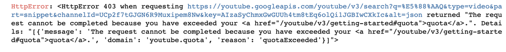

ref: https://developers.google.com/youtube/v3/getting-started#calculating-quota-usage

ref: https://developers.google.com/youtube/v3/docs/errors

所以來比較「中天電視」、「民視新聞網 Formosa TV News network」、「公視新聞網」就好...

```python
TV=['中天電視', '民視新聞網 Formosa TV News network', '公視新聞網']
TV_ENG=['CTI', 'Formosa', 'PTS']
ID=['UCpu3bemTQwAU8PqM4kJdoEQ', 'UC2VmWn8dAqkzlQqvy02E1PA', 'UCexpzYDEnfmAvPSfG4xbcjA']
# prevent API key exceed........ make sure the range
# print(ID)
# print(len(ID))
# print(type(ID))

RESULTS={'電視台頻道': TV,'頻道英文':TV_ENG,'channelID': ID}
RS = pd.DataFrame(data=RESULTS)
RS
```

|  | 電視台頻道 | 頻道英文 | channelID |
| --- | --- | --- | --- |
| 0 | 中天電視 | CTI | UCpu3bemTQwAU8PqM4kJdoEQ |
| 1 | 民視新聞網 Formosa TV News network | Formosa | UC2VmWn8dAqkzlQqvy02E1PA |
| 2 | 公視新聞網 | PTS | UCexpzYDEnfmAvPSfG4xbcjA |

```python
def QQQ_search(channelID):
    search_3QTotalResult = youtube.search().list(q="陳柏惟",type="video",part="snippet", channelId=channelID).execute()
    pageinfo=search_3QTotalResult.get('pageInfo')

    return pageinfo.get('totalResults')

num=[]
for i in range(len(ID)):
    num.append(QQQ_search(ID[i]))
print(num)
```

```
[90397, 59207, 2336]
```

```python
RESULTS["Total Video with 陳柏惟 titles"]=num
RS = pd.DataFrame(data=RESULTS)
RS
```

|  | 電視台頻道 | 頻道英文 | channelID | Total Video with 陳柏惟 titles |
| --- | --- | --- | --- | --- |
| 0 | 中天電視 | CTI | UCpu3bemTQwAU8PqM4kJdoEQ | 90397 |
| 1 | 民視新聞網 Formosa TV News network | Formosa | UC2VmWn8dAqkzlQqvy02E1PA | 59207 |
| 2 | 公視新聞網 | PTS | UCexpzYDEnfmAvPSfG4xbcjA | 2336 |

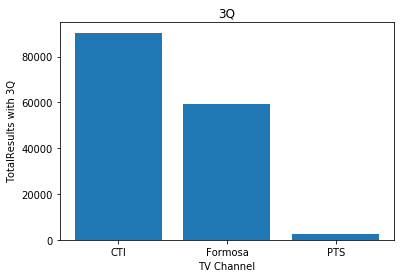

```python
plt.bar(TV_ENG, num)
#plt.xticks(x, TV)
plt.xlabel('TV Channel')
plt.ylabel('TotalResults with 3Q')
plt.title('3Q')
plt.show()
```

### 不同新聞頻道對「刪Q」搜尋下的 “Total Result”有何不同？

```python
def DQ_search(channelID):
    search_3QTotalResult = youtube.search().list(q="刪Q",type="video",part="snippet", channelId=channelID).execute()
    pageinfo=search_3QTotalResult.get('pageInfo')

    return pageinfo.get('totalResults')

DQnum=[]
for i in range(len(ID)):
    DQnum.append(DQ_search(ID[i]))
print(DQnum)
```

```
[106704, 13784, 166]
```

```python
RESULTS["Total Video with 刪Q titles"]=DQnum
RS = pd.DataFrame(data=RESULTS)
RS
```

|  | 電視台頻道 | 頻道英文 | channelID | Total Video with 陳柏惟 titles | Total Video with 刪Q titles |
| --- | --- | --- | --- | --- | --- |
| 0 | 中天電視 | CTI | UCpu3bemTQwAU8PqM4kJdoEQ | 90397 | 106704 |
| 1 | 民視新聞網 Formosa TV News network | Formosa | UC2VmWn8dAqkzlQqvy02E1PA | 59207 | 13784 |
| 2 | 公視新聞網 | PTS | UCexpzYDEnfmAvPSfG4xbcjA | 2336 | 166 |

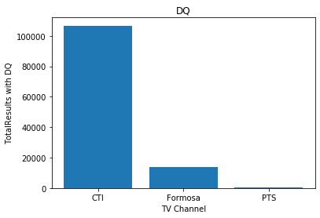

```python
plt.bar(TV_ENG, DQnum)
plt.xlabel('TV Channel')
plt.ylabel('TotalResults with DQ')
plt.title('DQ')
plt.show()
```

### 不同新聞頻道對「反惡罷」搜尋下的 “Total Result”有何不同？

```python
def AntiDQ_search(channelID):
    search_3QTotalResult = youtube.search().list(q="反惡罷",type="video",part="snippet", channelId=channelID).execute()
    pageinfo=search_3QTotalResult.get('pageInfo')

    return pageinfo.get('totalResults')

AntiDQnum=[]
for i in range(len(ID)):
    AntiDQnum.append(AntiDQ_search(ID[i]))
print(AntiDQnum)
```

```
[31172, 23504, 187]
```

```python
RESULTS["Total Video with 反惡罷 titles"]=AntiDQnum
RS = pd.DataFrame(data=RESULTS)
RS
```

|  | 電視台頻道 | 頻道英文 | channelID | Total Video with 陳柏惟 titles | Total Video with 刪Q titles | Total Video with 反惡罷 titles |
| --- | --- | --- | --- | --- | --- | --- |
| 0 | 中天電視 | CTI | UCpu3bemTQwAU8PqM4kJdoEQ | 90397 | 106704 | 31172 |
| 1 | 民視新聞網 Formosa TV News network | Formosa | UC2VmWn8dAqkzlQqvy02E1PA | 59207 | 13784 | 23504 |
| 2 | 公視新聞網 | PTS | UCexpzYDEnfmAvPSfG4xbcjA | 2336 | 166 | 187 |

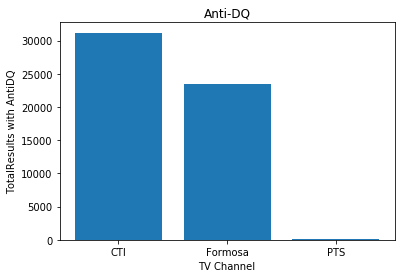

```python
plt.bar(TV_ENG, AntiDQnum)
plt.xlabel('TV Channel')
plt.ylabel('TotalResults with AntiDQ')
plt.title('Anti-DQ')
plt.show()
```

### 「刪Q」vs. 「反惡罷」

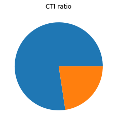

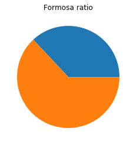

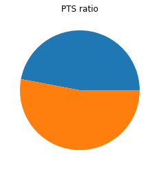

```python
CTI_ratio =[DQnum[0],AntiDQnum[0]]
plt.pie(CTI_ratio)
plt.title('CTI ratio')
plt.show()

For_ratio =[DQnum[1],AntiDQnum[1]]
plt.pie(For_ratio)
plt.title('Formosa ratio')
plt.show()

PTS_ratio =[DQnum[2],AntiDQnum[2]]
plt.pie(PTS_ratio)
plt.title('PTS ratio')
plt.show()
```

由繪製的圓餅圖不難發現，中天和民視都有報導傾向，中天多報導「刪Q」相關新聞，民視多報導「反惡罷」相關新聞。而公視還是有平衡報導。或許可以再調整時間軸看看，「刪Q」的新聞會不會在罷免成功後，有更多的報導數。

### Please submit this file to NTU COOL before next Monday (10/25).

```python
# NOTE:
# APIs service: https://console.cloud.google.com/apis/credentials?hl=zh-tw&project=scientific-mesh-330006

# The APIs Reference -- Resource Types
# Ref: https://developers.google.com/youtube/v3/docs
# APIs overall view
# Ref: https://developers.google.com/youtube/v3/getting-started#quota

# What's "build"?
# Ref: https://googleapis.github.io/google-api-python-client/docs/epy/googleapiclient.discovery-module.html

# What's "youtube.videos().list"?
# Ref: https://developers.google.com/youtube/v3/docs/videos/list
# result = youtube.videos().list(part='snippet,contentDetails,statistics',chart='mostPopular',
#         regionCode='TW',maxResults=50).execute()

# More details about Channel (Dependent on the parameter"id"setting)
#youtube.channels().list(part='brandingSettings, contentDetails, contentOwnerDetails, snippet, statistics, status, topicDetails',id="UClIfopQZlkkSpM1VgCFLRJA",maxResults=50, pageToken=None).execute()


# What does the Channel do? (Dependent on the parameter"channelId"setting)
# youtube.activities().list(part='snippet,contentDetails',channelId='UCO3bfz4KY6zGT5IOaFJuxpA',maxResults=50).execute()

# snippet: It shows the video thumbnail, title, and a link to the video on YouTube
```